# Course Project 1

Flor Anita Corredor

24/2/2021

# What is mean total number of steps taken per day?

1. Calculate the total number of steps taken per day
2. If you do not understand the difference between a histogram and a barplot, research the difference between them. Make a histogram of the total number of steps taken each day
3. Calculate and report the mean and median of the total number of steps taken per day

# 1. Number of steps per day

```r
StepsPerDay <- aggregate(steps ~ date, activity01, sum, na.rm=TRUE)
```

# 2. Histogram of the total number of steps taken each day

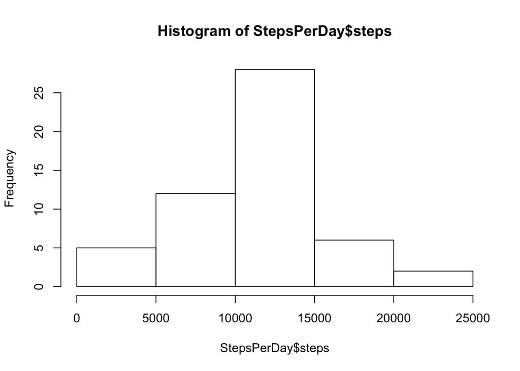

```r
hist(StepsPerDay$steps)
```

# 3. Mean and median of total number of steps taken per day

```r
# Mean
mean(StepsPerDay$steps, na.rm=TRUE)
```

```
## [1] 10766.19
```

```r
# Median
median(StepsPerDay$steps, na.rm=TRUE)
```

```
## [1] 10765
```

# What is the average daily activity pattern?

# 4. Time series plot of the average number of steps taken

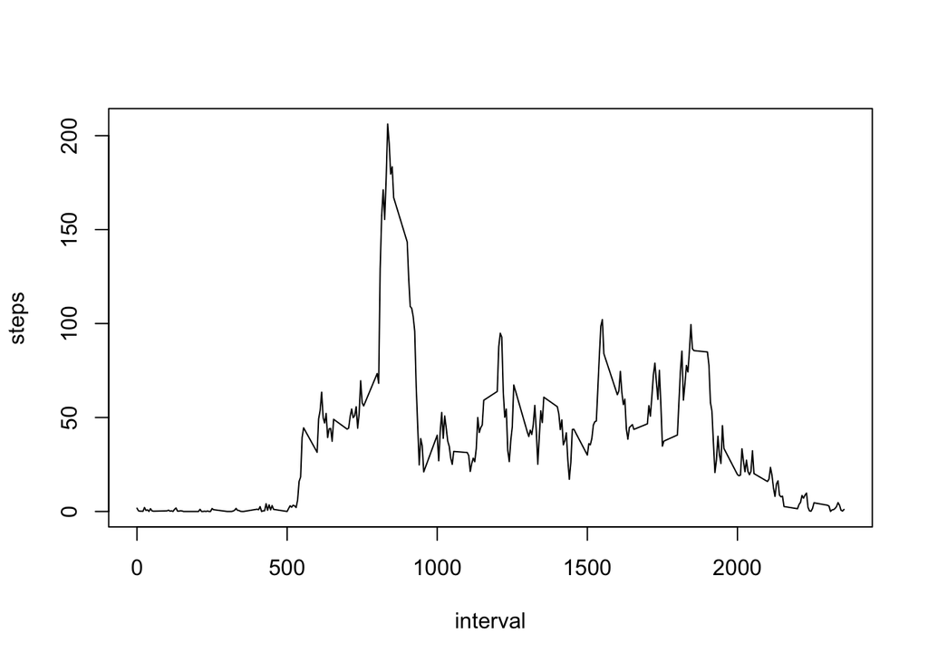

```r
StepsPerInterval<-aggregate(steps~interval, data=activity01, mean, na.rm=TRUE)
plot(steps~interval, data=StepsPerInterval, type="l")
```

# 5. The 5-minute interval that, on average, contains the maximum number of steps

```r
intervalWithMaxSteps <- StepsPerInterval[which.max(StepsPerInterval$steps),]$interval
```

[output not shown]

# Imputing missing values

1. Calculate and report the total number of missing values in the dataset (i.e. the total number of rows with NAs)

```r
sum(is.na(activity01$steps))
```

```
## [1] 2304
```

2. Devise a strategy for filling in all of the missing values in the dataset.

```r
getMeanPerInterval <-function(interval){
    StepsPerInterval[StepsPerInterval$interval==interval,]$steps
        }
```

3. Create a new dataset that is equal to the original dataset but with the missing data filled in.

```r
activity_NoNA<-activity01

for(i in 1:nrow(activity_NoNA)){
    if(is.na(activity_NoNA[i,]$steps)){
        activity_NoNA[i,]$steps <- getMeanPerInterval(activity_NoNA[i,]$interval)
    }
}
```

4. Histogram of the total number of steps taken each day

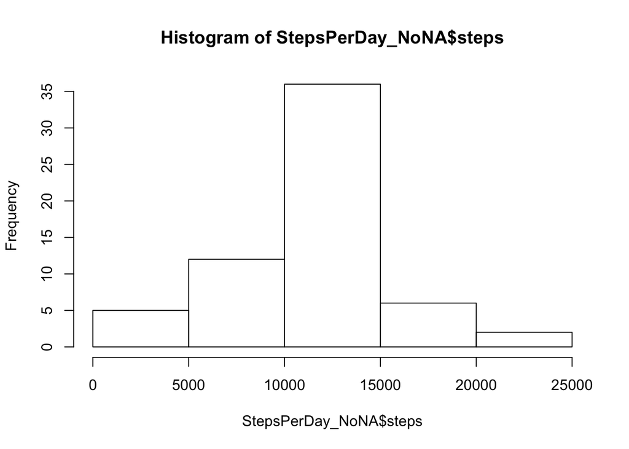

```r
StepsPerDay_NoNA <- aggregate(steps ~ date, data=activity_NoNA, sum)
hist(StepsPerDay_NoNA$steps)
```

Calculate and report the mean and median total number of steps taken per day.

```r
# Mean
mean(StepsPerDay_NoNA$steps)
```

```
## [1] 10766.19
```

```r
#Median
median(StepsPerDay_NoNA$steps)
```

```
## [1] 10766.19
```

Do these values differ from the estimates from the first part of the assignment? What is the impact of imputing missing data on the estimates of the total daily number of steps? Since I imputed the missing values by the mean number of steps per interval, there is no difference in mean before and after imputing that is not surprising. The median has changed a little bit.

# Are there differences in activity patterns between weekdays and weekends?

Create a new factor variable in the dataset with two levels – “weekday” and “weekend” indicating whether a given date is a weekday or weekend day.

```r
activity_NoNA$date <- as.Date(strptime(activity_NoNA$date, format="%Y-%m-%d"))
activity_NoNA$day <- weekdays(activity_NoNA$date)

for (i in 1:nrow(activity_NoNA)) {
    if (activity_NoNA[i,]$day %in% c("Saturday","Sunday")) {
        activity_NoNA[i,]$day<-"weekend"
    }
    else{
        activity_NoNA[i,]$day<-"weekday"
    }
}

steps_days <- aggregate(steps ~ interval + day, activity_NoNA, mean)
```

Make a panel plot containing a time series plot (i.e. type = “l”) of the 5-minute interval (x-axis) and the average number of steps taken, averaged across all weekday days or weekend days (y-axis). See the README file in the GitHub repository to see an example of what this plot should look like using simulated data.

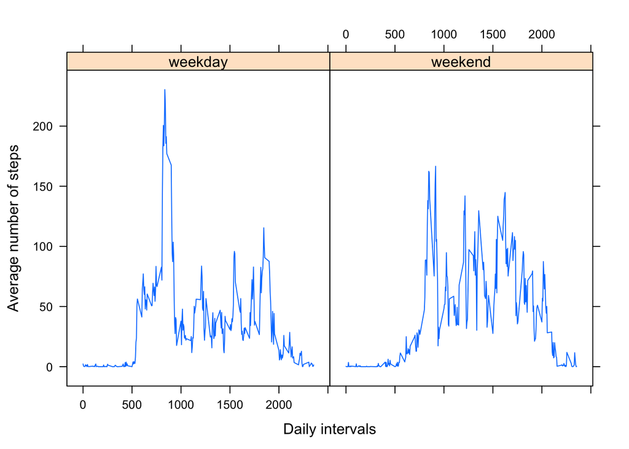

```r
library(lattice)
xyplot(steps ~ interval | day, steps_days, type = "l", layout = c(2,1),
       xlab = "Daily intervals", ylab = "Average number of steps")
```